# UsingNumpy

### 线性代数（Linear algebra）

通常情况下，线性代数的函数都可以在scipy.linalg中找到。此外还可以使用BLAS 和 LAPACK 函数，这需要使用 scipy.linagl.blas 和 scipy.linalg.lapack。

```python
import scipy.linalg as la
```

```python
A = np.array([[1,2],[3,4]])
b = np.array([1,4])
print(A)
print(b)
```

```
[[1 2]
 [3 4]]
[1 4]
```

```python
# 矩阵运算
import numpy as np
import scipy.linalg as la
from functools import reduce

A = np.array([[1,2],[3,4]])
print(np.dot(A, A))
print(A)
print(la.inv(A))
print(A.T)
```

```
[[ 7 10]
 [15 22]]
[[1 2]
 [3 4]]
[[-2.   1. ]
 [ 1.5 -0.5]]
[[1 3]
 [2 4]]
```

```python
x = la.solve(A, b) # 不要使用 x = dot(inv(A), b)因为这样效率很低，而且可靠性也不行
print(x)
print(np.dot(A, x) - b)
```

```
[ 2.  -0.5]
[ 0.  0.]
```

### 矩阵分解（Matrix decompositions）

```python
A = np.floor(npr.normal(100, 15, (6, 10)))
print(A)
```

```
[[  94.   82.  125.  108.  105.   88.   99.   82.   97.  112.]
 [  83.  124.   67.  103.   73.  111.  125.   81.  122.   62.]
 [  93.   84.  107.  107.   80.   85.   96.   89.   85.  102.]
 [ 116.  116.   64.   98.   82.   98.  121.   70.  122.   98.]
 [ 118.  108.  103.  102.   68.   98.   88.   78.  103.   95.]
 [ 112.  115.   74.   80.  106.  104.  114.  105.   80.   99.]]
```

```python
P, L, U = la.lu(A)
print(np.dot(P.T, A))
print
print(np.dot(L, U))
```

```
[[ 118.  108.  103.  102.   68.   98.   88.   78.  103.   95.]
 [  83.  124.   67.  103.   73.  111.  125.   81.  122.   62.]
 [  94.   82.  125.  108.  105.   88.   99.   82.   97.  112.]
 [ 116.  116.   64.   98.   82.   98.  121.   70.  122.   98.]
 [ 112.  115.   74.   80.  106.  104.  114.  105.   80.   99.]
 [  93.   84.  107.  107.   80.   85.   96.   89.   85.  102.]]

[[ 118.  108.  103.  102.   68.   98.   88.   78.  103.   95.]
 [  83.  124.   67.  103.   73.  111.  125.   81.  122.   62.]
 [  94.   82.  125.  108.  105.   88.   99.   82.   97.  112.]
 [ 116.  116.   64.   98.   82.   98.  121.   70.  122.   98.]
 [ 112.  115.   74.   80.  106.  104.  114.  105.   80.   99.]
 [  93.   84.  107.  107.   80.   85.   96.   89.   85.  102.]]
```

```python
Q, R = la.qr(A)
print(A)
print
print(np.dot(Q, R))
```

```
[[  94.   82.  125.  108.  105.   88.   99.   82.   97.  112.]
 [  83.  124.   67.  103.   73.  111.  125.   81.  122.   62.]
 [  93.   84.  107.  107.   80.   85.   96.   89.   85.  102.]
 [ 116.  116.   64.   98.   82.   98.  121.   70.  122.   98.]
 [ 118.  108.  103.  102.   68.   98.   88.   78.  103.   95.]
 [ 112.  115.   74.   80.  106.  104.  114.  105.   80.   99.]]

[[  94.   82.  125.  108.  105.   88.   99.   82.   97.  112.]
 [  83.  124.   67.  103.   73.  111.  125.   81.  122.   62.]
 [  93.   84.  107.  107.   80.   85.   96.   89.   85.  102.]
 [ 116.  116.   64.   98.   82.   98.  121.   70.  122.   98.]
 [ 118.  108.  103.  102.   68.   98.   88.   78.  103.   95.]
 [ 112.  115.   74.   80.  106.  104.  114.  105.   80.   99.]]
```

```python
U, s, V = la.svd(A)
m, n = A.shape
S =  np.zeros((m, n))
for i, _s in enumerate(s):
    S[i,i] = _s
print(reduce(np.dot, [U, S, V]))
```

```
[[  94.   82.  125.  108.  105.   88.   99.   82.   97.  112.]
 [  83.  124.   67.  103.   73.  111.  125.   81.  122.   62.]
 [  93.   84.  107.  107.   80.   85.   96.   89.   85.  102.]
 [ 116.  116.   64.   98.   82.   98.  121.   70.  122.   98.]
 [ 118.  108.  103.  102.   68.   98.   88.   78.  103.   95.]
 [ 112.  115.   74.   80.  106.  104.  114.  105.   80.   99.]]
```

```python
B = np.cov(A)
print(B)
```

```
[[ 187.7333 -182.4667   94.9333 -105.4444    1.2    -137.2   ]
 [-182.4667  609.6556  -83.3111  371.0556   90.8778   70.5667]
 [  94.9333  -83.3111   97.2889  -48.8889   45.0222  -79.8   ]
 [-105.4444  371.0556  -48.8889  438.5     145.5     109.0556]
 [   1.2      90.8778   45.0222  145.5     215.4333  -39.7667]
 [-137.2      70.5667  -79.8     109.0556  -39.7667  234.1   ]]
```

```python
u, V = la.eig(B)
print(np.dot(B, V))
print
print(np.real(np.dot(V, np.diag(u))))
```

```
[[-280.8911  157.1032   12.1003  -60.7161    8.8142   -1.5134]
 [ 739.1179   34.4268    3.8974    4.3778   14.9092 -122.8749]
 [-134.1449  128.3162  -11.0569   -6.6382   37.3675   13.4467]
 [ 598.7992   77.4348   -5.3372  -52.7843  -14.996    94.553 ]
 [ 170.8339  193.7335    5.8732   67.6135    1.1042   90.1451]
 [ 199.7105 -218.1547    6.1467   -5.6295   26.3372  101.0444]]

[[-280.8911  157.1032   12.1003  -60.7161    8.8142   -1.5134]
 [ 739.1179   34.4268    3.8974    4.3778   14.9092 -122.8749]
 [-134.1449  128.3162  -11.0569   -6.6382   37.3675   13.4467]
 [ 598.7992   77.4348   -5.3372  -52.7843  -14.996    94.553 ]
 [ 170.8339  193.7335    5.8732   67.6135    1.1042   90.1451]
 [ 199.7105 -218.1547    6.1467   -5.6295   26.3372  101.0444]]
```

```python
C = la.cholesky(B)
print(np.dot(C.T, C))
print
print(B)
```

```
[[ 187.7333 -182.4667   94.9333 -105.4444    1.2    -137.2   ]
 [-182.4667  609.6556  -83.3111  371.0556   90.8778   70.5667]
 [  94.9333  -83.3111   97.2889  -48.8889   45.0222  -79.8   ]
 [-105.4444  371.0556  -48.8889  438.5     145.5     109.0556]
 [   1.2      90.8778   45.0222  145.5     215.4333  -39.7667]
 [-137.2      70.5667  -79.8     109.0556  -39.7667  234.1   ]]

[[ 187.7333 -182.4667   94.9333 -105.4444    1.2    -137.2   ]
 [-182.4667  609.6556  -83.3111  371.0556   90.8778   70.5667]
 [  94.9333  -83.3111   97.2889  -48.8889   45.0222  -79.8   ]
 [-105.4444  371.0556  -48.8889  438.5     145.5     109.0556]
 [   1.2      90.8778   45.0222  145.5     215.4333  -39.7667]
 [-137.2      70.5667  -79.8     109.0556  -39.7667  234.1   ]]
```

### 查找协方差矩阵

```python
np.random.seed(123)
x = np.random.multivariate_normal([10,10], np.array([[3,1],[1,5]]), 10)
# 创建一个零均值的数组（zero mean array）
u = x - x.mean(0)
cov = np.dot(u.T, u)/(10-1)
print cov, '\n'
print np.cov(x.T)
```

```
[[ 5.1286  3.0701]
 [ 3.0701  9.0755]]

[[ 5.1286  3.0701]
 [ 3.0701  9.0755]]
```

### 最小二乘法（Least squares solution）

假设我们要解决下面的这个有噪音的线性方程系统（a system of noisy linear equations）：

$$ y_1 = b_0 x_1 + b_1 \\ y_2 = b_0 x_2 + b_1 \\ y_3 = b_0 x_2 + b_1 \\ y_4 = b_0 x_4 + b_1 \\ $$

由于这个系统有噪音，也就意味着是满秩（full rank）而且超定（overdetermined），所以就不能找到一个确定的解。这样我们就要尝试使用最小二乘法了。首先把这个方程改写成矩阵的形式$Y = AB$, 然后用 $b_1$ 作为 $x^0 = 1$的系数（coefficient）：

$$ \left( \begin{array}{c} y_1 \\ y_2 \\ y_3 \\ y_4 \end{array} \right) = \left( \begin{array}{cc} x_1 & 1 \\ x_2 & 1 \\ x_3 & 1 \\ x_4 & 1 \end{array} \right) \left( \begin{array}{cc} b_0 & b_1 \end{array} \right) $$

这个方程的解(也就是矩阵 $B$)可以通过将$A$ (Vandermonde 矩阵 matrix)的伪逆矩阵（psudo-inverse）和矩阵 $Y$ 相乘而得到：

$$ (A^\text{T}A)^{-1}A^\text{T} Y $$

注意，更高阶的多项式（higher order polynomials）也有同样的结构，所以也可以这么来求解。

$$ \left( \begin{array}{c} y_1 \\ y_2 \\ y_3 \\ y_4 \end{array} \right) = \left( \begin{array}{ccc} x_1^2 & x_1 & 1 \\ x_2^2 & x_2 & 1 \\ x_3^2 & x_3 & 1 \\ x_4^2 & x_4 & 1 \end{array} \right) \left( \begin{array}{ccc} b_0 & b_1 & b_2 \end{array} \right) $$

```
('lstsq solution                ', array([ 5.5899, -1.4177]))
('pseudoinverse solution        ', array([ 5.5899, -1.4177]))
('normal euqation solution      ', array([ 5.5899, -1.4177]))
```

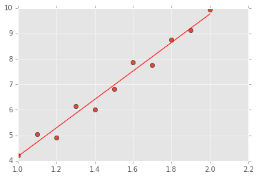

```python
# 建立一个系统来解 11 元素的线性方程（Set up a system of 11 linear equations）
x = np.linspace(1,2,11)
y = 6*x - 2 + npr.normal(0, 0.3, len(x))

# 创建 VanderMonde 矩阵
A = np.vstack([x, np.ones(len(x))]).T

# 线性代数库中有一个最小二乘法函数lstsq() ，这个就能替我们搞定上面计算过程了

b, resids, rank, sv = la.lstsq(A, y)

# 检查一下伪逆矩阵和法方程（Check against pseudoinverse and the normal equation）
print("lstsq solution".ljust(30), b)
print("pseudoinverse solution".ljust(30), np.dot(la.pinv(A), y))
print("normal euqation solution".ljust(30), np.dot(np.dot(la.inv(np.dot(A.T, A)), A.T), y))

# 然后把解出来的值投图
xi = np.linspace(1,2,11)
yi = b[0]*xi + b[1]

plt.plot(x, y, 'o')
plt.plot(xi, yi, 'r-');
```

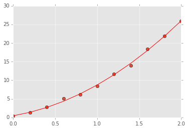

```python
# 再来广告一下，这个思路也可以用来解多项式的系数（coeefficeints of a polynomial）

x = np.linspace(0,2,11)
y = 6*x*x + .5*x + 2 + npr.normal(0, 0.6, len(x))
plt.plot(x, y, 'o')
A = np.vstack([x*x, x, np.ones(len(x))]).T
b = la.lstsq(A, y)[0]

xi = np.linspace(0,2,11)
yi = b[0]*xi*xi + b[1]*xi + b[2]
plt.plot(xi, yi, 'r-');
```

```
[(6, -250.9964),
 (7, 819.7606),
 (1, -909.5724),
 (5, 449.7862),
 (7, -91.2660),
 (9, 15.5274)]
```

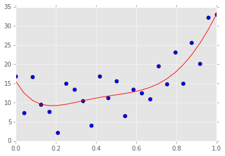

```python
# 一定要理解这每一步都是啥意思，在做什么，理解是最重要的！
# 但只要理解了就行了，而具体去计算这些多项式拟合之类的事情，并不用咱们亲自动手，而是交给程序来进行

b = np.random.randint(0, 10, 6)
x = np.linspace(0, 1, 25)
y = np.poly1d(b)(x)
y += np.random.normal(0, 5, y.shape)

p = np.poly1d(np.polyfit(x, y, len(b)-1))
plt.plot(x, y, 'bo')
plt.plot(x, p(x), 'r-')
list(zip(b, p.coeffs))
```

## 练习

**1**. 找出下面这个矩阵的各行、列以及整体的均值

```
m = np.arange(12).reshape((3,4))
```

```python
# YOUR CODE HERE
```

**2**. 计算下面向量的外积（outer product）

```
u = np.array([1,3,5,7])
v = np.array([2,4,6,8])
```

用下面的方式来进行：

- 使用numpy当中的`outer`函数
- 使用一个嵌套循环或者列表推导式
- 使用numpy的广播（broadcasting operatoins）

```python
# YOUR CODE HERE
```

[output not shown]

变成

```
array([[ 0.        ,  0.        ,  0.        ,  0.        ,  0.        ,
         0.        ],
       [ 0.        ,  0.        ,  0.        ,  0.        ,  0.        ,
         0.        ],
       [ 0.74821206,  0.92692111,  0.24871227,  0.26904958,  0.80410194,
         0.22304055],
       [ 0.22582605,  0.37671244,  0.96510957,  0.88819053,  0.14654176,
         0.33987323]])
```

提示：使用下面这几个numpy的函数 - `np.random.random`, `np.any` 以及布尔值索引（Boolean indexing）和坐标轴变量（axis argument）。

```python
# YOUR CODE HERE
```

**4**. 使用`np.linspace` 创建一个数组，其中有100个数值，这些数值在 0 到 $2\pi$ 之间(包括这两个端点值，includsive).

- 使用切片操作来每十个抽出来第十个元素（Extract every 10th element using slice notation）
- 使用切片操作将数组逆向
- 抽取所有正弦（sine）和余弦值（cosine）相差小于0.1的数值
- 给这个数组进行投图

```python
# YOUR CODE HERE
```

**5**. 创建一个矩阵，来显示一个 10*10 的乘法表

- 找出矩阵的迹（trace）
- 提取出对角线（anto-diagonal） (应该是 `array([10, 18, 24, 28, 30, 30, 28, 24, 18, 10])`)
- 提取对角线（diagnoal）并且向上偏移1（offset by 1 upwards） (得到的结果应该是`array([ 2, 6, 12, 20, 30, 42, 56, 72, 90])`)

```python
# YOUR CODE HERE
```

**6**. 将下面的矩阵对角线化（Diagonalize）

```
A = np.array([
    [1,  2, 1],
    [6, -1, 0],
    [-1,-2,-1]
])
```

详细来说，就是先找到逆矩阵（invertible matrix） $P$，以及对角矩阵（diagonal matrix） $D$ 。然后计算一下$P^{-1}DP $的值，来验证一下。

- 手动进行这个计算
- 然后使用numpy.linalg 函数来做同样的效果

```python
# YOUR CODE HERE
```

**7**. 用下面给出的函数来对矩阵运算进行可视化，转成对矩阵 $m$的值进行修改而对应的几何变换。（Use the function provided below to visualize matrix multiplication as a geometric transformation by experiment with differnt values of the matrix $m$.）

- 一个对角矩阵对原来的向量进行了什么操作？
- 一个不可逆矩阵（non-invertible matrix）对原始向量有何效果？
- 矩阵的什么属性能够表示由两个向量限定的平行四边形的面积？
- 矩阵的什么属性能够表示原始向量的长度和角度？
- 还需要什么额外的属性来保留原始向量的方向？
- 保留原始向量的长度和角度的矩阵的转置矩阵的效果是什么？
- 写一个函数，当给定任何两个非共线的二维向量u，v时，找到一种变换，将u转换为e1（1,0）和v转换成e2（0,1）。

```python
#  给出的函数
def plot_matrix_transform(m):
    """Show the geometric effect of m on the standard unit vectors e1 and e2."""

    e1 = np.array([1,0])
    e2 = np.array([0,1])
    v1 = np.dot(m, e1)
    v2 = np.dot(m, e2)

    X = np.zeros((2,2))
    Y = np.zeros((2,2))
    pts = np.array([e1,e2,v1,v2])
    U = pts[:, 0]
    V = pts[:, 1]
    C = [0,1,0,1]

    xmin = min(-1, U.min())
    xmax = max(1, U.max())
    ymin = min(-1, V.min())
    ymax = max(-1, V.max())

    plt.figure(figsize=(6,6))
    plt.quiver(X, Y, U, V, C, angles='xy', scale_units='xy', scale=1)
    plt.axis([xmin, xmax, ymin, ymax]);
```

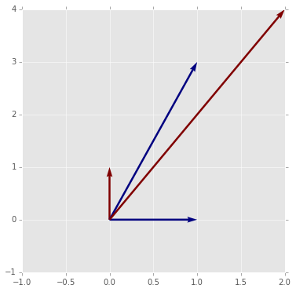

```python
### 样例使用
m = np.array([[1,2],[3,4]])
plot_matrix_transform(m)
```

```python
# YOUR CODE HERE
```

**8**. 针对给定的$x$ 和 $y$按照下面的方式来进行最小二乘拟合并投图：

- 常数值（a constant）
- 二次方程（a quadratic equation）
- 五次多项式（a 5th order polynomial）
- 一个阶数为50的多项式（polynomial of order 50）

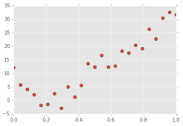

```python
x = np.load('x.npy')
y = np.load('y.npy')
plt.plot(x, y, 'o')

### YOUR CODE HERE
```

```python
%load_ext version_information

%version_information numpy, scipy
```

| Software | Version |
| --- | --- |
| Python | 2.7.9 64bit [GCC 4.2.1 (Apple Inc. build 5577)] |
| IPython | 2.3.1 |
| OS | Darwin 13.4.0 x86_64 i386 64bit |
| numpy | 1.9.1 |
| scipy | 0.14.0 |
| Sun Jan 18 10:29:33 2015 EST |  |